# Bar chart

- A bar chart is used when we want to compare metric values across different subgroups of the data. If we have a greater number of groups, a bar chart is preferred over a column chart.

## Bar chart using Matplotlib

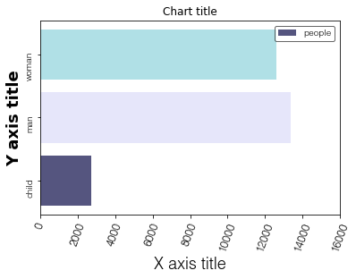

```python
import seaborn as sns
import matplotlib.pyplot as plt
import matplotlib.pyplot as plt
import matplotlib.font_manager as fm
path = 'D:/Installed/Fonts/'
namefont=['iOS-Helvetica.ttf','Tahoma.ttf','iOS-Helvetica-Light.ttf','IOS7HelveticaNeue-CondensedBlack.ttf']
fpath=path+namefont[2]
fontprop = fm.FontProperties(fname=fpath)
#Creating the dataset
df = sns.load_dataset('titanic')
df=df.groupby('who')['fare'].sum().to_frame().reset_index()

#Creating the bar chart
plt.barh(df['who'],df['fare'],color = [(85/255, 85/255, 127/255),'#E6E6FA','#B0E0E6'],label='people')
plt.grid(color='gray', linestyle='-', linewidth=2, which='both',alpha =0.8)
#Adding the aesthetics
plt.title('Chart title')
plt.xlabel('X axis title',fontweight='bold',fontproperties=fontprop, fontsize =18)
plt.ylabel('Y axis title',fontweight='bold',fontsize =18)
plt.xticks(fontproperties=fontprop, fontsize =12,rotation=70)
plt.yticks(fontproperties=fontprop, fontsize =10,rotation=90)

plt.xlim(0,16000)
legend = plt.legend(loc=1,  #bbox_to_anchorloc=[0.1,0.35, 0.95, 0.65],
         ncol=2,  borderaxespad=0.6,prop=fontprop,labelspacing=1,edgecolor='black',framealpha=0.6),#,mode="expand

plt.grid(False)
#plt.axis('off')
#Show the plot
dir_out = 'G:/My Drive/VTCA/Hieu/less_7/'
plt.savefig(dir_out+'bar.png',dpi =600, pad_inches=0.01)
plt.show()
```

## Bar chart using Seaborn

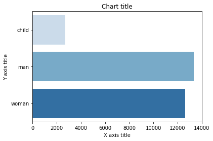

```python
titanic_dataset=df

#Creating bar plot
#plt.style.use('seaborn-dark-palette')
#sns.set_style("darkgrid")
sns.barplot(x = 'fare',y = 'who',data = titanic_dataset,palette = "Blues")
#Adding the aesthetics
plt.title('Chart title')
plt.xlabel('X axis title')
plt.ylabel('Y axis title')
# Show the plot
plt.show()
```

# Column chart

- Column charts are mostly used when we need to compare a single category of data between individual sub-items, for example, when comparing revenue between regions

## Column chart using Matplotlib

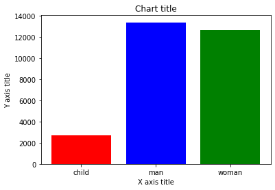

```python
#Creating the dataset
df = sns.load_dataset('titanic')
df=df.groupby('who')['fare'].sum().to_frame().reset_index()
#Creating the column plot
plt.bar(df['who'],df['fare'],color = ['r','b','g'])
#Adding the aesthetics
plt.title('Chart title')
plt.xlabel('X axis title')
plt.ylabel('Y axis title')
#Show the plot
plt.show()
```

## Column chart using Seaborn

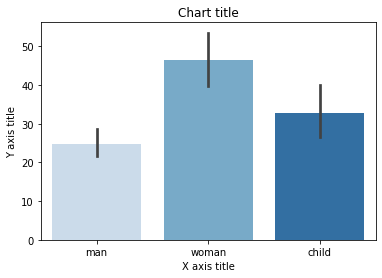

```python
#Reading the dataset
titanic_dataset = sns.load_dataset('titanic')
#Creating column chart
sns.barplot(x = 'who',y = 'fare',data = titanic_dataset,palette = "Blues")
#Adding the aesthetics
plt.title('Chart title')
plt.xlabel('X axis title')
plt.ylabel('Y axis title')
# Show the plot
plt.show()
```

# Grouped bar chart

- A grouped bar chart is used when we want to compare the values in certain groups and sub-groups

## Grouped bar chart using Matplotlib

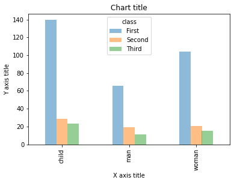

```python
import pandas as pd
import numpy as np

#Creating the dataset
df = sns.load_dataset('titanic')
df_pivot = pd.pivot_table(df, values="fare",index="who",columns="class", aggfunc=np.mean)
#Creating a grouped bar chart
ax = df_pivot.plot(kind="bar",alpha=0.5)
#Adding the aesthetics
plt.title('Chart title')
plt.xlabel('X axis title')
plt.ylabel('Y axis title')
# Show the plot
plt.show()
```

## Grouped bar chart using Seaborn

```python
titanic_dataset.head()
```

|  | survived | pclass | sex | age | sibsp | parch | fare | embarked | class | who | adult_male | deck | embark_town | alive | alone |
| --- | --- | --- | --- | --- | --- | --- | --- | --- | --- | --- | --- | --- | --- | --- | --- |
| 0 | 0 | 3 | male | 22.0 | 1 | 0 | 7.2500 | S | Third | man | True | NaN | Southampton | no | False |
| 1 | 1 | 1 | female | 38.0 | 1 | 0 | 71.2833 | C | First | woman | False | C | Cherbourg | yes | False |
| 2 | 1 | 3 | female | 26.0 | 0 | 0 | 7.9250 | S | Third | woman | False | NaN | Southampton | yes | True |
| 3 | 1 | 1 | female | 35.0 | 1 | 0 | 53.1000 | S | First | woman | False | C | Southampton | yes | False |
| 4 | 0 | 3 | male | 35.0 | 0 | 0 | 8.0500 | S | Third | man | True | NaN | Southampton | no | True |

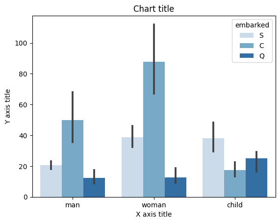

```python
import seaborn as sns
import matplotlib.pyplot as plt
#Reading the dataset
titanic_dataset = sns.load_dataset('titanic')
#Creating the bar plot grouped across classes
sns.barplot(x = 'who',y = 'fare',hue = 'embarked',data = titanic_dataset, palette = "Blues")
#Adding the aesthetics
plt.title('Chart title')
plt.xlabel('X axis title')
plt.ylabel('Y axis title')
# Show the plot
#plt.show()
```

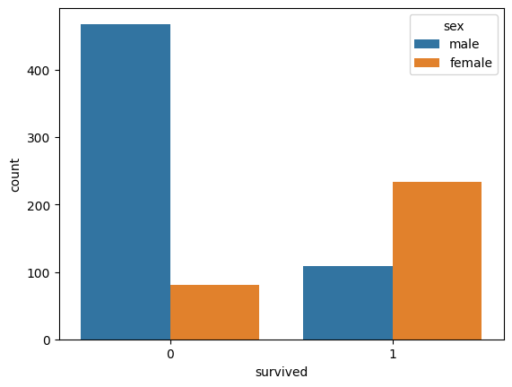

```python
sns.countplot(titanic_dataset['survived'],hue=titanic_dataset['sex'])
```

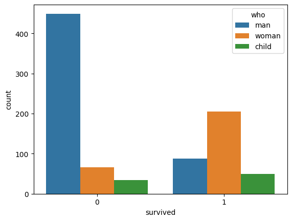

```python
sns.countplot(titanic_dataset['survived'],hue=titanic_dataset['who'])
```

```python
titanic_dataset.info()
```

```
<class 'pandas.core.frame.DataFrame'>
RangeIndex: 891 entries, 0 to 890
Data columns (total 15 columns):
 #   Column       Non-Null Count  Dtype
---  ------       --------------  -----
 0   survived     891 non-null    int64
 1   pclass       891 non-null    int64
 2   sex          891 non-null    object
 3   age          714 non-null    float64
 4   sibsp        891 non-null    int64
 5   parch        891 non-null    int64
 6   fare         891 non-null    float64
 7   embarked     889 non-null    object
 8   class        891 non-null    category
 9   who          891 non-null    object
 10  adult_male   891 non-null    bool
 11  deck         203 non-null    category
 12  embark_town  889 non-null    object
 13  alive        891 non-null    object
 14  alone        891 non-null    bool
dtypes: bool(2), category(2), float64(2), int64(4), object(5)
memory usage: 80.7+ KB
```